# Water and Economy Xiaojing Ni - Financial Time Series Models

Author

Xiaojing Ni

## Water treatment provider

Due to the climate change and human activities, extreme climate and environment events, such as the water crisis caused by eutrophication in City of Toledo, OH, occur more frequently ([Climate change indicators](https://www.epa.gov/climate-indicators/weather-climate)), and may be regularly. This phenomenon brings opportunities for environmental companies such as water treatment firm. Xylem Inc. is a large American water technology provider, in public utility, residential, commercial, agricultural and industrial settings. The company was founded in 2011 and does business in more than 150 countries ([Wiki](https://en.wikipedia.org/wiki/Xylem_Inc.)). In this report, the stock of Xylem was modeled using financial time series models, such as ARMA+GARCH to forecast the volatility of future returns.

### Xylem stock prices

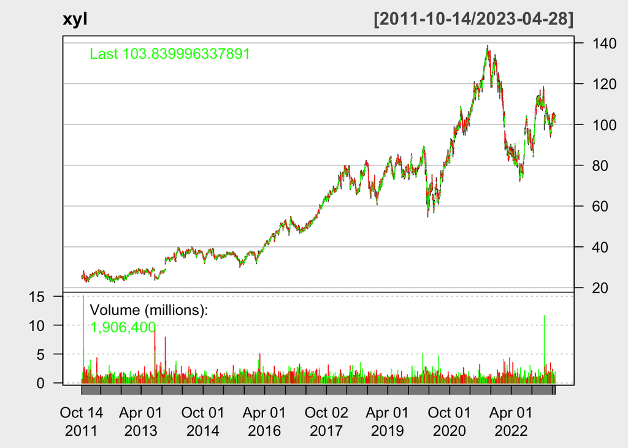

Figure 1: Xylem Inc. stock price 2011-2023

```r
## read data since 2011
xyl <- getSymbols("XYL",auto.assign = FALSE, from = "2011-10-14",src="yahoo")
xyl$date<-as.Date(xyl$date,"%Y-%m-%d")

chartSeries(xyl, theme = chartTheme("white"), # Theme
            bar.type = "hlc",  # High low close
            up.col = "green",  # Up candle color
            dn.col = "red")   # Down candle color)


xyl.close<- Ad(xyl)
```

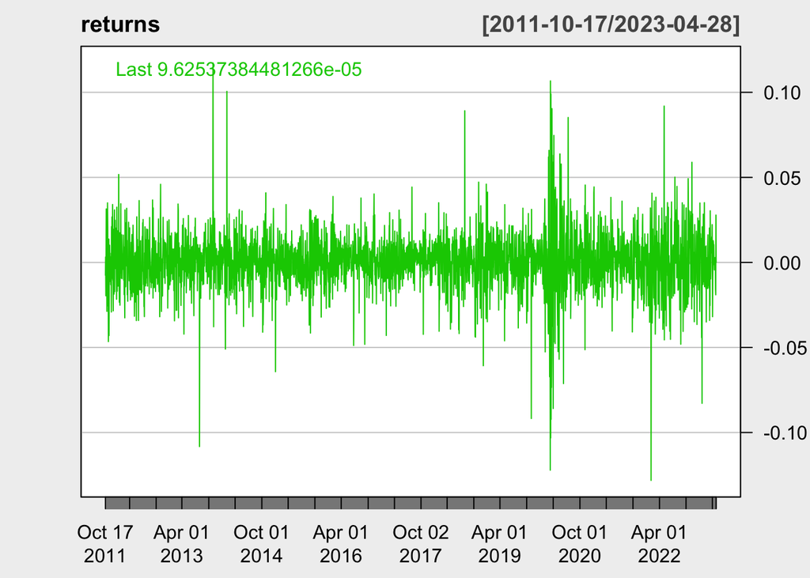

Figure 2: Returns 2011-2023

```r
returns = diff(log(xyl.close))

chartSeries(returns, theme="white")
```